# GLMs: Applications of Multilevel Models

## Fitting multilevel models

Among the options for R packages:

- `nlme`: Oldest, restricted to a subset of models (linear and non-linear Gaussian), *for us the place to start*
- `lme4`: Newer (but same authors as `nlme`), can handle more complex models with crossed random effects, pedigrees, non-Gaussian response, etc., more flexible distributions of response variables, but harder to test hypotheses
- `MCMCglmm`, `rstan`, `rjags`: Fit Bayesian multilevel models via a variety of MCMC samplers

## Long-finned squid (*Loligo forbesii*)

[figure not shown]

Seasonal patterns in testis mass in the squid *Loligo*. Testis mass predicted by dorsal mantle length, month, and DML X month.

## `Squid` data

```r
Sq <- read_excel("../data/Squid.xlsx")
Sq <- Sq %>% mutate(Month = factor(Month))
str(Sq)
```

```
## tibble [768 × 5] (S3: tbl_df/tbl/data.frame)
##  $ Specimen   : num [1:768] 1017 1034 1070 1070 1019 ...
##  $ Year       : num [1:768] 1991 1990 1990 1990 1990 ...
##  $ Month      : Factor w/ 12 levels "1","2","3","4",..: 2 9 12 11 8 10 5 7 7 7 ...
##  $ DML        : num [1:768] 136 144 108 130 121 117 133 105 109 97 ...
##  $ Testis_Mass: num [1:768] 0.006 0.008 0.008 0.011 0.012 0.012 0.013 0.015 0.017 0.017 ...
```

```r
# Check for missing data
sum(!complete.cases(Sq))
```

```
## [1] 0
```

## Visualizing

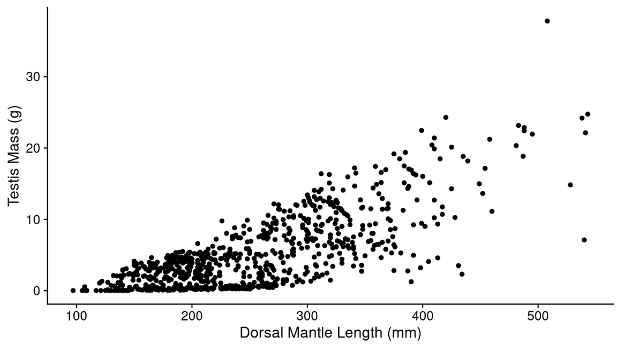

## Visualizing

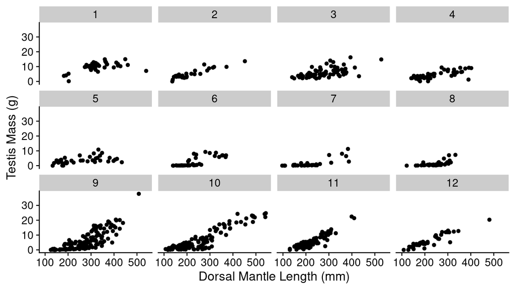

## Multiple regression

Testis mass modeled by `DML`, `Month`, and the `DML` by `Month` interaction:

```r
fm1 <- lm(Testis_Mass ~ DML + Month + DML:Month, data = Sq)
```

Extract the residuals and fitted values:

```r
Sq$Res1 <- residuals(fm1)
Sq$Fitted <- fitted.values(fm1)
```

## Residuals vs. Fitted Values

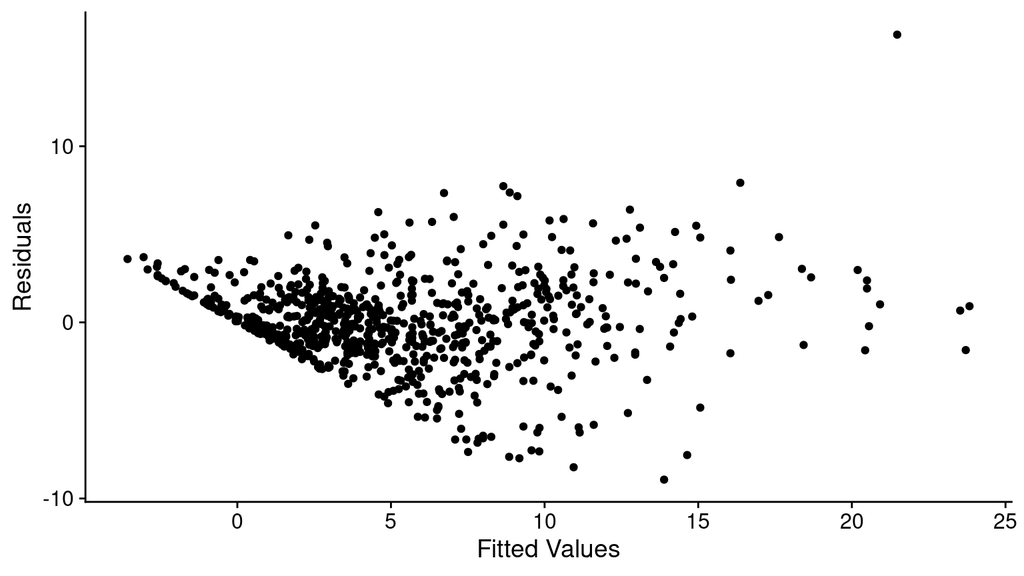

## Residuals vs. Month

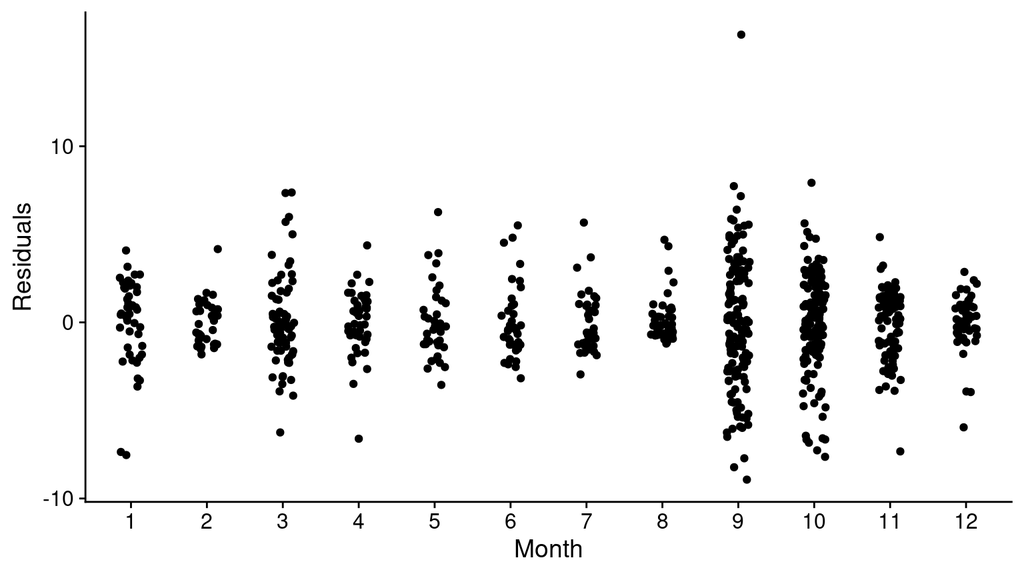

## Dealing with heterogeneity within groups

**What we need**:

1. Allow for change in variance with values of `DML` (here, more spread with larger values)
2. Allow for difference variances per month

**Solution**:

- Generalized least squares \(\approx\) “Weighted regression”
- `nlme::gls()`

## Fitting a weighted regression

```r
library(nlme)
variance_struct <- varPower(form = ~ DML | Month)
```

- This structure allows the *residual* variance to change with `DML` on a per-`Month` basis.
- Here a power relationship
  - Other variance structures available

```r
fm2 <- gls(Testis_Mass ~ DML * Month, data = Sq,
           weights = variance_struct)
```

## Diagnostics

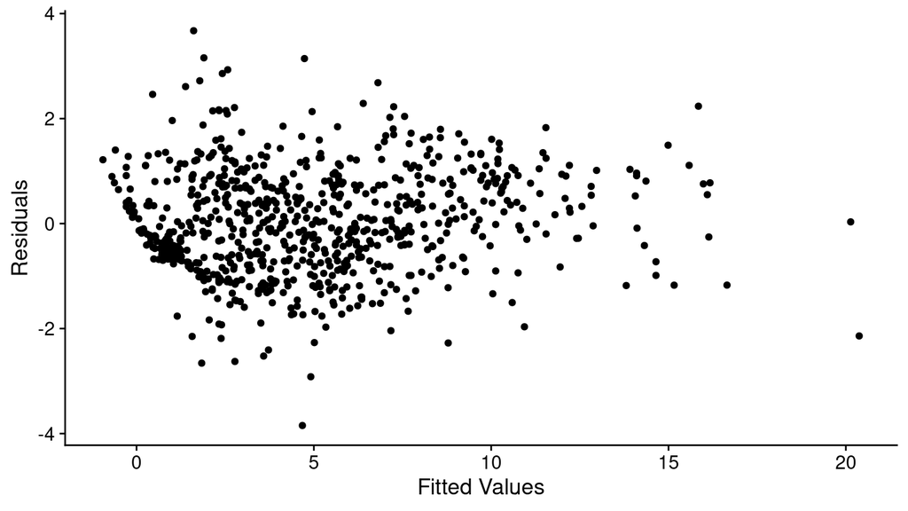

## Summary

```r
library(car)
Anova(fm2, type = "III")
```

```
## Analysis of Deviance Table (Type III tests)
##
## Response: Testis_Mass
##             Df   Chisq Pr(>Chisq)
## (Intercept)  1  12.829  0.0003412 ***
## DML          1  97.683  < 2.2e-16 ***
## Month       11 131.398  < 2.2e-16 ***
## DML:Month   11 263.768  < 2.2e-16 ***
## ---
## Signif. codes:  0 '***' 0.001 '**' 0.01 '*' 0.05 '.' 0.1 ' ' 1
```

## Visualization of the model

```r
Sq$Res2 <- residuals(fm2, type = "normalized")
```

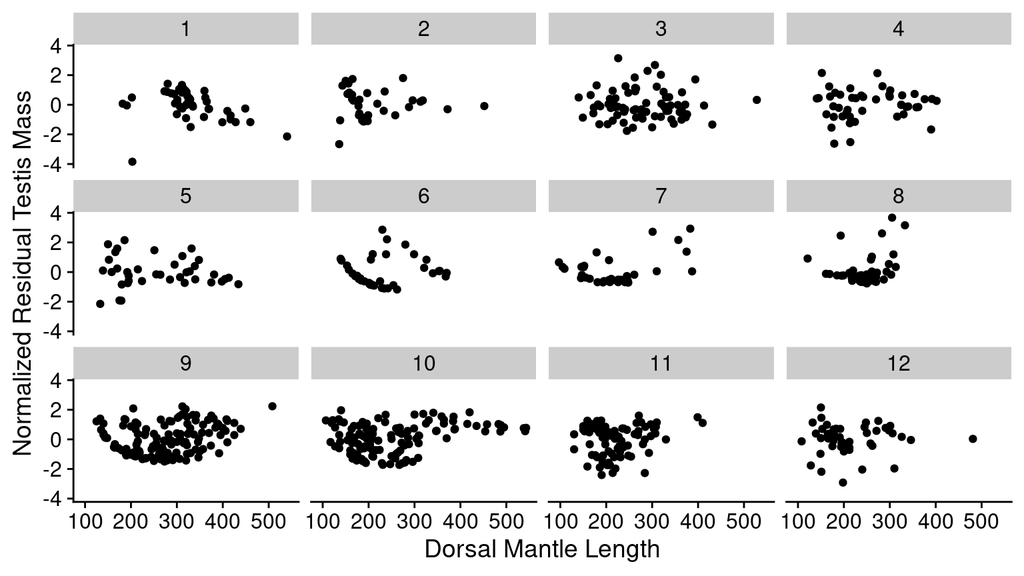

## Visualization of the model

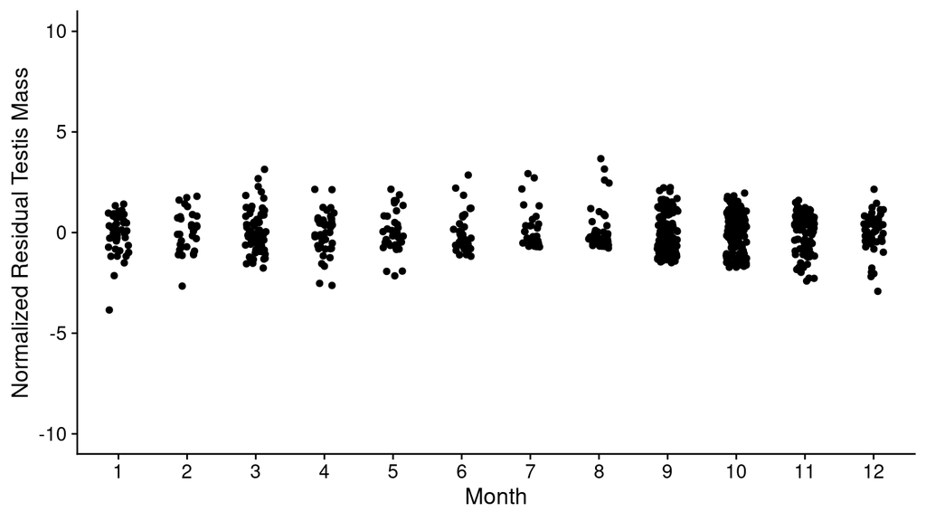

## Coefficients

```
##                coef(fm2)
## (Intercept) -4.780766117
## DML          0.046586768
## Month2       1.334832688
## Month3       3.661164039
## Month4       3.410049731
## Month5       3.952996105
## Month6      -0.666479296
## Month7       3.669033636
## Month8       3.241214275
## Month9      -1.646991712
## Month10      0.520155071
## Month11     -1.742289244
## Month12     -0.957233528
## DML:Month2  -0.007741092
## DML:Month3  -0.020683055
## DML:Month4  -0.023432938
## DML:Month5  -0.028570692
## DML:Month6  -0.012384220
## DML:Month7  -0.036970988
## DML:Month8  -0.036261111
## DML:Month9  -0.002745299
## DML:Month10 -0.008961514
## DML:Month11  0.007326402
## DML:Month12  0.007205552
```

## Nested data

Data with hierarchical structure:

- *i* samples within *n* blocks

We could just take a means of each block and use those data for ANOVA.

- Lose all the information about variability within blocks
- Might increase apparent variance

## Intertidal species richness

Collected by National Institute for Coastal and Marine Management (RIKZ)

[figure not shown]

## Intertidal data

```r
RIKZ <- read_excel("../data/RIKZ.xlsx")
glimpse(RIKZ)
```

```
## Rows: 45
## Columns: 5
## $ Sample   <dbl> 1, 2, 3, 4, 5, 6, 7, 8, 9, 10, 11, 12, 13, 14, 15, 16, 17, 1…
## $ Richness <dbl> 11, 10, 13, 11, 10, 8, 9, 8, 19, 17, 6, 1, 4, 3, 3, 1, 3, 3,…
## $ Exposure <dbl> 10, 10, 10, 10, 10, 8, 8, 8, 8, 8, 11, 11, 11, 11, 11, 11, 1…
## $ NAP      <dbl> 0.045, -1.036, -1.336, 0.616, -0.684, 1.190, 0.820, 0.635, 0…
## $ Beach    <dbl> 1, 1, 1, 1, 1, 2, 2, 2, 2, 2, 3, 3, 3, 3, 3, 4, 4, 4, 4, 4, …
```

- `Richness`: Number of species
- `NAP`: Height above mean tidal level
- `Exposure`: Index composed of wave action, length of the surf zone, slope, grain size, and the depth of the anaerobic layer

## Preparing data

Convert `Beach` to factor.

```r
RIKZ <- RIKZ %>% mutate(Beach = factor(Beach))
```

## Sampling structure

[figure not shown]

Sites are the level of the observation.

## Sampling structure

```r
RIKZ %>% group_by(Beach) %>% tally()
```

```
## # A tibble: 9 x 2
##   Beach     n
## * <fct> <int>
## 1 1         5
## 2 2         5
## 3 3         5
## 4 4         5
## 5 5         5
## 6 6         5
## 7 7         5
## 8 8         5
## 9 9         5
```

5 observations at each of 9 beaches

## Visualizing `NAP`

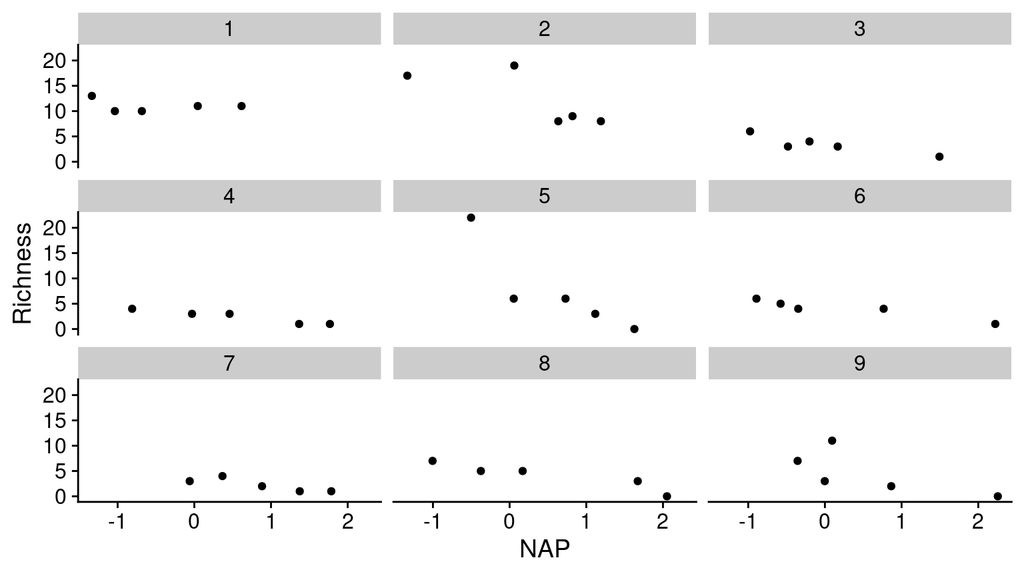

## Visualizing `Exposure`

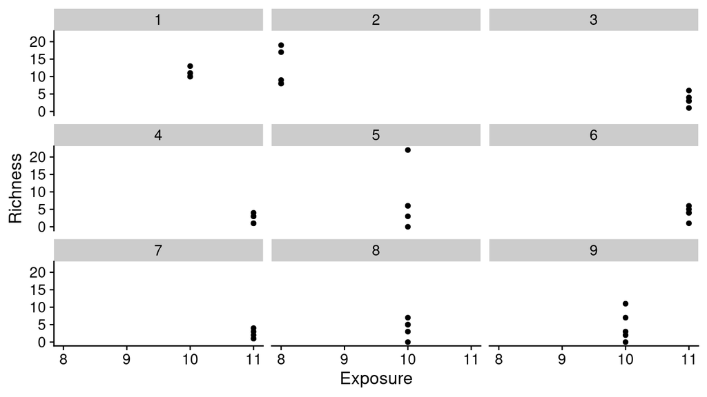

Each `Beach` only has 1 value of `Exposure`.

## Naive multiple regression model

```r
fm1 <- lm(Richness ~ NAP + Beach, data = RIKZ)
Anova(fm1, type = "III")
```

```
## Anova Table (Type III tests)
##
## Response: Richness
##             Sum Sq Df F value    Pr(>F)
## (Intercept) 466.37  1 49.8039 3.224e-08 ***
## NAP         230.66  1 24.6322 1.793e-05 ***
## Beach       416.37  8  5.5581 0.0001441 ***
## Residuals   327.74 35
## ---
## Signif. codes:  0 '***' 0.001 '**' 0.01 '*' 0.05 '.' 0.1 ' ' 1
```

## Naive multiple regression model

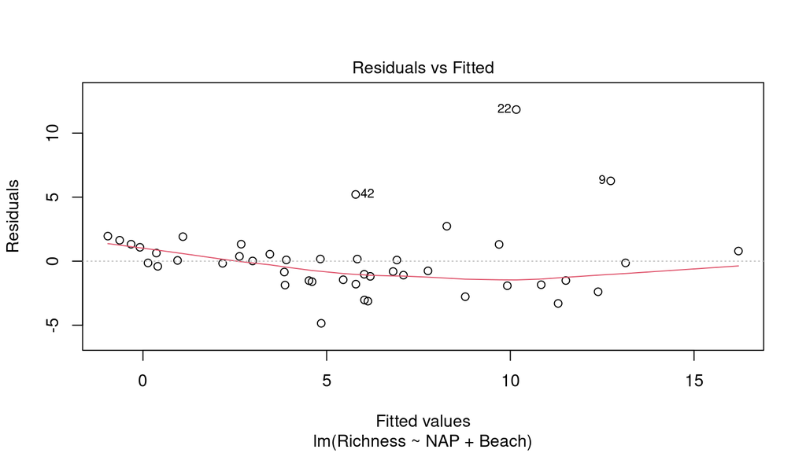

Maybe we are not interested in knowing the exact nature of the beach effect.

## Multilevel model

Allow a different mean richness per beach:

```r
fm2 <- lme(Richness ~ NAP, random = ~ 1 | Beach, data = RIKZ)
```

## Diagnostics

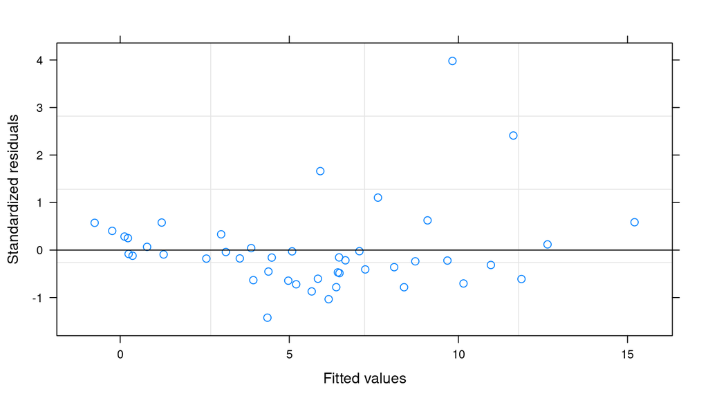

```r
plot(fm2)
```

## Summary

```
## Linear mixed-effects model fit by REML
##   Data: RIKZ
##        AIC     BIC    logLik
##   247.4802 254.525 -119.7401
##
## Random effects:
##  Formula: ~1 | Beach
##         (Intercept) Residual
## StdDev:    2.944065  3.05977
##
## Fixed effects:  Richness ~ NAP
##                 Value Std.Error DF   t-value p-value
## (Intercept)  6.581893 1.0957618 35  6.006682       0
## NAP         -2.568400 0.4947246 35 -5.191574       0
##  Correlation:
##     (Intr)
## NAP -0.157
##
## Standardized Within-Group Residuals:
##        Min         Q1        Med         Q3        Max
## -1.4227495 -0.4848006 -0.1576462  0.2518966  3.9793918
##
## Number of Observations: 45
## Number of Groups: 9
```

## Visualizing the model

Generate predicted values for overall population level estimates and within beach estimates.

```r
# Overall
RIKZ$Pred0 <- fitted(fm2, level = 0)

# Within beach
RIKZ$Pred1 <- fitted(fm2, level = 1)
```

## Visualizing the model

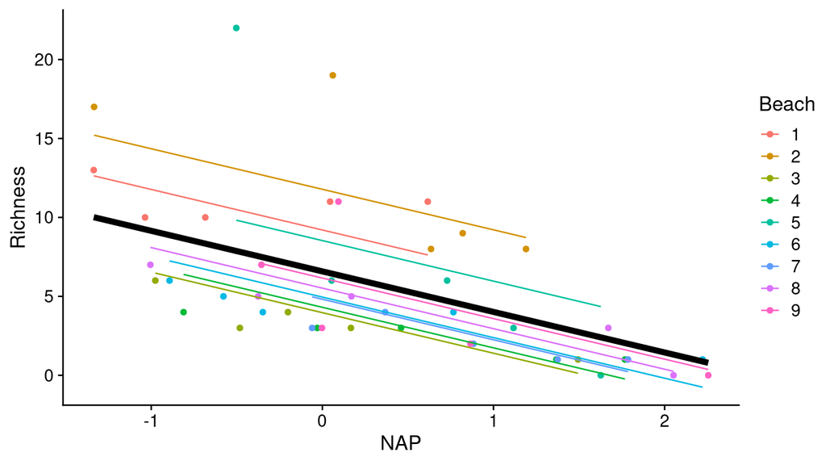

## Does the relationship differ per beach?

Allow each `Beach` to have its own `NAP` to `Richness` linear relationship:

```r
fm3 <- lme(Richness ~ NAP, random = ~ NAP | Beach, data = RIKZ)
```

Now the `NAP` to `Richness` relationship can vary for each `Beach`.

## Summary

```r
summary(fm3)
```

```
## Linear mixed-effects model fit by REML
##   Data: RIKZ
##        AIC      BIC    logLik
##   244.3839 254.9511 -116.1919
##
## Random effects:
##  Formula: ~NAP | Beach
##  Structure: General positive-definite, Log-Cholesky parametrization
##             StdDev   Corr
## (Intercept) 3.549064 (Intr)
## NAP         1.714963 -0.99
## Residual    2.702820
##
## Fixed effects:  Richness ~ NAP
##                 Value Std.Error DF   t-value p-value
## (Intercept)  6.588706  1.264761 35  5.209448   0e+00
## NAP         -2.830028  0.722940 35 -3.914610   4e-04
##  Correlation:
##     (Intr)
## NAP -0.819
##
## Standardized Within-Group Residuals:
##        Min         Q1        Med         Q3        Max
## -1.8213326 -0.3411043 -0.1674617  0.1921216  3.0397049
##
## Number of Observations: 45
## Number of Groups: 9
```

## Visualizing the model

Generate predicted values for overall population level estimates and within beach estimates.

```r
# Overall
RIKZ$Pred0 <- fitted(fm3, level = 0)

# Within beach
RIKZ$Pred1 <- fitted(fm3, level = 1)
```

## Visualizing the model

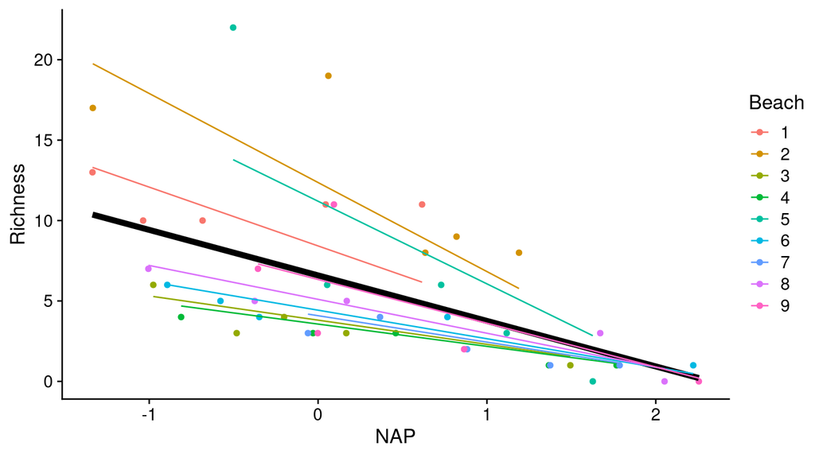

## Coefficients

```
##   (Intercept)       NAP
## 1    8.421057 -3.656268
## 2   12.363497 -5.536814
## 3    3.806643 -1.505716
## 4    3.562422 -1.385960
## 5   11.200150 -5.137323
## 6    4.426279 -1.775675
## 7    4.082944 -1.644329
## 8    5.099895 -2.106852
## 9    6.335471 -2.721314
```

## Longitudinal studies

Sequential measurements of the same individual / plot / organism, etc. will result in within-subject correlation.

- Growth curves
- Long-term ecological monitoring

## Cranial growth rates in children

Distance from the sella turcica to the pterygomaxillary fissure in growing children.

[figure not shown]

## Orthodontics data

```r
O <- read_excel("../data/Ortho.xlsx")
O <- O %>% mutate(Subject = factor(Subject),
                  Sex = factor(Sex))
glimpse(O)
```

```
## Rows: 108
## Columns: 4
## $ Distance <dbl> 26.0, 25.0, 29.0, 31.0, 21.5, 22.5, 23.0, 26.5, 23.0, 22.5, …
## $ Age      <dbl> 8, 10, 12, 14, 8, 10, 12, 14, 8, 10, 12, 14, 8, 10, 12, 14, …
## $ Subject  <fct> M01, M01, M01, M01, M02, M02, M02, M02, M03, M03, M03, M03, …
## $ Sex      <fct> Male, Male, Male, Male, Male, Male, Male, Male, Male, Male, …
```

## Orthodontics data

```r
O %>% group_by(Sex) %>% tally()
```

```
## # A tibble: 2 x 2
##   Sex        n
## * <fct>  <int>
## 1 Female    44
## 2 Male      64
```

```r
range(O$Age)
```

```
## [1]  8 14
```

Potthoff, R. F. and Roy, S. N. (1964) A generalized multivariate analysis of variance model useful especially for growth curve problems. *Biometrika* 51: 313-326.

## Visualizing

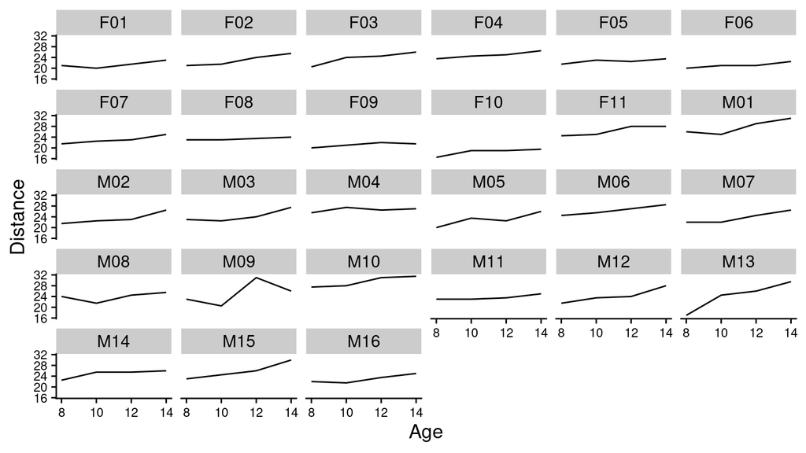

## Visualizing

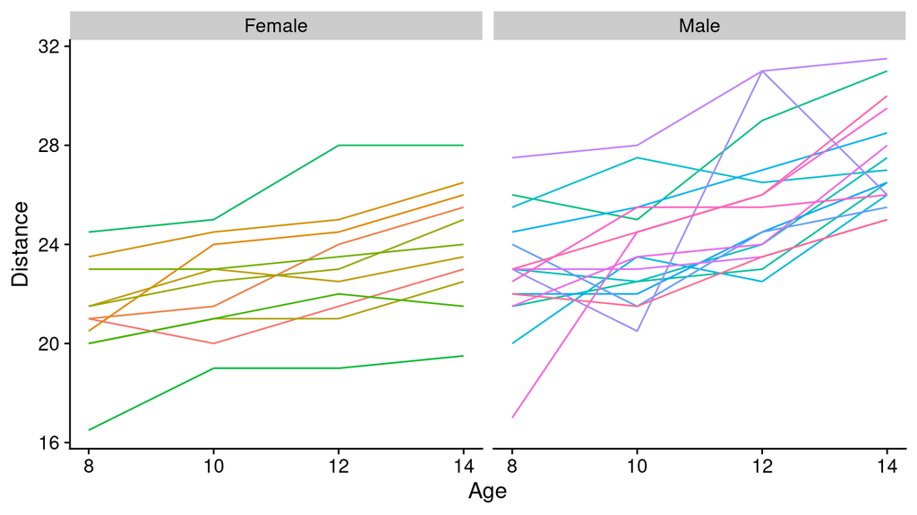

## What are the growth patterns of the head in boys and girls?

- Main effects of `Age` and `Sex` (like an ANCOVA model).
- Random effects allow the `Age` by `Distance` relationship (slope) to vary for each `Subject`, which is also allowed to have its own mean.

```r
fm2 <- lme(Distance ~ Sex + Age, random = ~ Age | Subject,
           method = "ML",
           data = O)
```

## Predicted values

```r
# Overall
O$Pred0 <- fitted(fm2, level = 0)

# Age within Subject
O$Pred1 <- fitted(fm2, level = 1)
```

## Visualizing

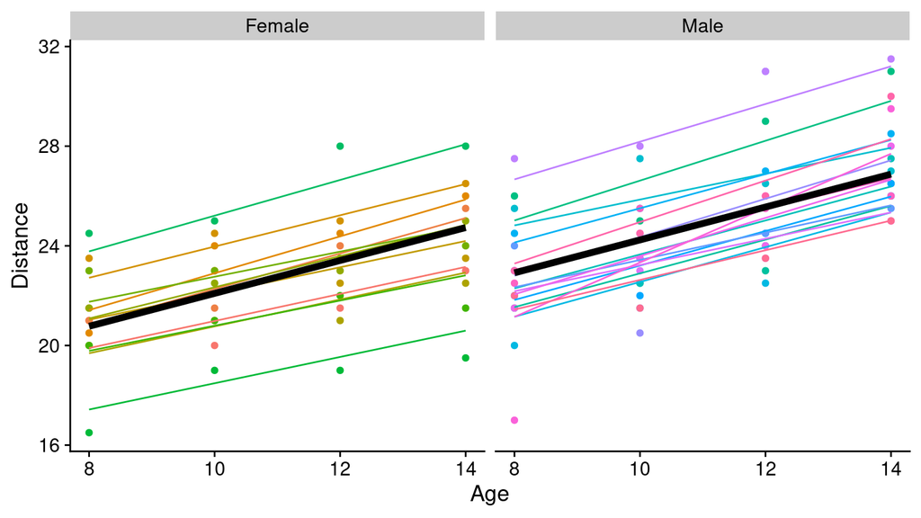

## Summary

```
## Linear mixed-effects model fit by maximum likelihood
##   Data: O
##        AIC      BIC    logLik
##   446.8352 465.6101 -216.4176
##
## Random effects:
##  Formula: ~Age | Subject
##  Structure: General positive-definite, Log-Cholesky parametrization
##             StdDev    Corr
## (Intercept) 2.6447350 (Intr)
## Age         0.2149243 -0.76
## Residual    1.3100397
##
## Fixed effects:  Distance ~ Sex + Age
##                 Value Std.Error DF   t-value p-value
## (Intercept) 15.489709 0.9328629 80 16.604486  0.0000
## SexMale      2.145491 0.7391991 25  2.902453  0.0076
## Age          0.660185 0.0709131 80  9.309772  0.0000
##  Correlation:
##         (Intr) SexMal
## SexMale -0.470
## Age     -0.792  0.000
##
## Standardized Within-Group Residuals:
##         Min          Q1         Med          Q3         Max
## -3.16563246 -0.45463448  0.01446427  0.44559465  3.90045094
##
## Number of Observations: 108
## Number of Groups: 27
```

## ANOVA table

```r
Anova(fm2, type = "III")
```

```
## Analysis of Deviance Table (Type III tests)
##
## Response: Distance
##                Chisq Df Pr(>Chisq)
## (Intercept) 283.5863  1  < 2.2e-16 ***
## Sex           8.6649  1   0.003244 **
## Age          89.1482  1  < 2.2e-16 ***
## ---
## Signif. codes:  0 '***' 0.001 '**' 0.01 '*' 0.05 '.' 0.1 ' ' 1
```

## Reasons to use multilevel models

Adapted from McElreath (2015)

1. *To adjust estimates for repeat sampling*. When more than one observation arises from the same individual, location, or time, then traditional, single-level models may mislead us.
2. *To adjust estimates for imbalance in sampling*. When some individuals, locations, or times are sampled more than others, we may also be misled by single-level models.
3. *To study variation*. If research questions include variation among individuals or other groups within the data, multilevel models help, because they model variation explicitly.
4. *To avoid averaging*. Avoid pre-average to construct variables for a regression analysis. Averaging removes variation. Multilevel models allow us to preserve the uncertainty in the original, pre-averaged values, while still using the average to make predictions.

## Can poor experimental design be saved by multilevel models?

No.

## References

McElreath, R. 2015. *Statistical Rethinking: A Bayesian Course with Examples in R and Stan*. Chapman; Hall/CRC, Boca Raton, FL.